# 3.2.4

We'll make use of the fact that if $f$ is odd (that is, $f(-x) = -f(x)$ for all $x$) we know "symmetric" integrals vanish:

$$ \int_{-a}^a f(x)\,dx = 0.$$

This is clear graphically, or can be seen by substituting $u = -x, du = -dx$ and changing bounds to see

$$\int_{-a}^0 f(x) \, dx = \int_{a}^0 f(-u) \, (-du) = \int_0^a (-f(u)) \, du = - \int_0^a f(x) \, dx.$$

Similarly, if $f$ is even (that is, $f(-x)=f(x)$ for all $x$) we have

$$\int_{-a}^a f(x) \,dx = 2 \int_0^a f(x) \, dx.$$

Also, note the product of an even and odd function is odd, and the product of two odd functions is even (not how even and odd integers behave!)

## (a)

$$f(x) = x$$

We have $x$ and $x \cos \dfrac{n \pi x}{L}$ are odd, while $x \sin \dfrac{n \pi x}{L}$ is even. Therefore, using integration by parts for $b_n$ we have

\begin{align*} a_0 &= \frac{1}{2L} \int_{-L}^L x \, dx = 0, \\ \\ a_n &= \frac{1}{L} \int_{-L}^L x \cos \frac{n \pi x}{L} \, dx = 0, \\ \\ b_n &= \frac{1}{L} \int_{-L}^L x \sin \frac{n \pi x }{L} \, dx \\ &= \frac 2 L \int_0^L \underbrace{x}_{u} \underbrace{\sin \frac{n \pi x}{L}}_{dv} \, dx \\ &= - \frac 2 L \cdot x \frac{L}{n \pi} \cos \frac{n \pi x}{L} \Big|_0^L + \frac 2 L \cdot \frac{L}{n \pi} \int_0^L \cos \frac{n \pi x}{L} \, dx \\ &= - \frac{2L}{n \pi} \cos(n\pi) + \frac 2 L \cdot \frac{L^2}{n^2 \pi^2} \sin \frac{n \pi x}{L} \Big|_0^L \\ &= - \frac{2(-1)^nL}{n \pi}. \end{align*}

Therefore,

$$\boxed{x \sim \sum_{n=1}^\infty \frac{2(-1)^{n+1}L}{n \pi} \sin \frac{n \pi x}{L} \quad \text{ on } [-L,L]}.$$

We can check our answer with SymPy, and plot the $2L$-periodic extension:

$\displaystyle f(x)\sim a_0 + \sum_{n=1}^\infty a_n \cos \left( \dfrac{n \pi x}{L} \right)+\sum_{n=1}^\infty b_n \sin \left( \dfrac{n \pi x}{L}\right) \text{ on } [-L,L]\\[1em]$

$\displaystyle a_0 = 0 \\[1em]$

$\displaystyle a_n = 0\\[1em]$

$\displaystyle b_n = - \frac{2 \left(-1\right)^{n} L}{\pi n}\\[1em]$

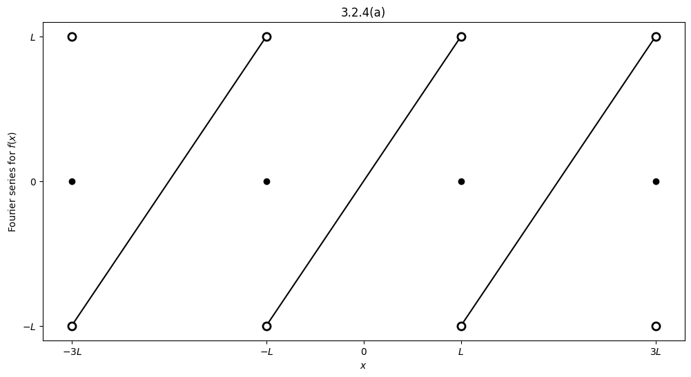

## (b)

$$f(x) = e^{-x}$$

We can "indirectly" solve for these integrals using integration by parts twice. Let's call

\begin{align*} I &:= \int \underbrace{e^{-x}}_{u} \underbrace{\cos ax}_{dv} \, dx\\ &= \frac 1 a e^{-x} \sin a x + \frac 1 a \int \underbrace{e^{-x}}_{u}\underbrace{ \sin ax}_{dv} \, dx \\ &= \frac 1 a e^{-x} \sin ax - \frac{1}{a^2} e^{-x} \cos ax - \frac{1}{a^2} \int e^{-x} \cos ax \,dx \\ &= \frac 1 a e^{-x} \sin ax - \frac{1}{a^2} e^{-x} \cos ax - \frac{1}{a^2} I. \end{align*}

Rearranging and solving for $I$ yields

$$ \int e^{-x} \cos ax \, dx = \frac{1}{1 + \frac{1}{a^2}} \left( \frac 1 a e^{-x} \sin ax - \frac{1}{a^2} e^{-x} \cos ax\right) = \frac{a^2}{a^2 + 1} \left( \frac 1 a e^{-x} \sin ax - \frac{1}{a^2} e^{-x} \cos ax\right) = \frac{1}{a^2+1} \left( ae^{-x} \sin ax - e^{-x} \cos ax\right).$$

Similarly, let's call

\begin{align*} I &:= \int \underbrace{e^{-x}}_{u} \underbrace{\sin ax}_{dv} \, dx\\ &= -\frac 1 a e^{-x} \cos a x - \frac 1 a \int \underbrace{e^{-x}}_{u}\underbrace{ \cos ax}_{dv} \, dx \\ &= -\frac 1 a e^{-x} \cos ax - \left(\frac{1}{a^2} e^{-x} \sin ax + \frac{1}{a^2} \int e^{-x} \sin ax \,dx\right) \\ &= -\frac 1 a e^{-x} \cos ax - \frac{1}{a^2} e^{-x} \sin ax - \frac{1}{a^2} I. \end{align*}

Rearranging and solving for $I$ yields

$$ \int e^{-x} \sin ax \, dx = -\frac{1}{1 + \frac{1}{a^2}} \left( \frac 1 a e^{-x} \cos ax + \frac{1}{a^2} e^{-x} \sin ax\right) = -\frac{a^2}{a^2 + 1} \left( \frac 1 a e^{-x} \cos ax + \frac{1}{a^2} e^{-x} \sin ax\right) = -\frac{1}{a^2+1} \left( ae^{-x} \cos ax + e^{-x} \sin ax\right).$$

Then, for $f(x) = e^{-x}$ we have (recognizing $\sinh(L) = \dfrac{e^L-e^{-L}}{2}$)

$$\boxed{a_0} = \frac{1}{2L} \int e^{-x} \, dx = - \frac{1}{2L} e^{-x} \Big|_{-L}^L = - \frac{1}{2L} (e^{-L}-e^{L}) = \boxed{\frac 1 L \sinh(L)}.$$

Then, (using the fact that cosine is even so $\cos(n\pi) = \cos(-n\pi)$)

\begin{align*} \boxed{a_n} &= \frac{1}{L} \int_{-L}^L e^{-x} \cos \frac{n \pi x}{L} \, dx \\ &= \frac{1}{L} \cdot \frac{e^{-x}}{\left(\frac{n^2\pi^2}{L^2}\right)+1} \left[ \frac{n\pi}{L} \sin \frac{n\pi x}{L} - \cos \frac{n \pi x}{L} \right] \Big|_{-L}^L \\ &= \frac{L}{n^2 \pi^2 + L^2} (e^{-L} - e^{L})[-\cos(n\pi)] \\ &= \boxed{\frac{2(-1)^nL}{n^2 \pi^2 + L^2} \sinh(L)}. \end{align*}

Similarly,

\begin{align*} \boxed{b_n} &= \frac{1}{L} \int_{-L}^L e^{-x} \sin \frac{n \pi x}{L} \, dx \\ &= -\frac{1}{L} \cdot \frac{e^{-x}}{\left(\frac{n^2\pi^2}{L^2}\right)+1} \left[ \frac{n\pi}{L} \cos \frac{n\pi x}{L} + \sin \frac{n \pi x}{L} \right] \Big|_{-L}^L \\ &= -\frac{n\pi}{n^2 \pi^2 + L^2} (e^{-L} - e^{L})[\cos(n\pi)] \\ &= \boxed{\frac{2(-1)^n n \pi}{n^2 \pi^2 + L^2} \sinh(L)}. \end{align*}

We can check our answer with SymPy, and plot the $2L$-periodic extension:

$\displaystyle f(x)\sim a_0 + \sum_{n=1}^\infty a_n \cos \left( \dfrac{n \pi x}{L} \right)+\sum_{n=1}^\infty b_n \sin \left( \dfrac{n \pi x}{L}\right) \text{ on } [-L,L]\\[1em]$

$\displaystyle a_0 = \frac{\sinh{\left(L \right)}}{L} \\[1em]$

$\displaystyle a_n = \frac{2 \left(-1\right)^{n} L \sinh{\left(L \right)}}{L^{2} + \pi^{2} n^{2}}\\[1em]$

$\displaystyle b_n = \frac{2 \left(-1\right)^{n} \pi n \sinh{\left(L \right)}}{L^{2} + \pi^{2} n^{2}}\\[1em]$

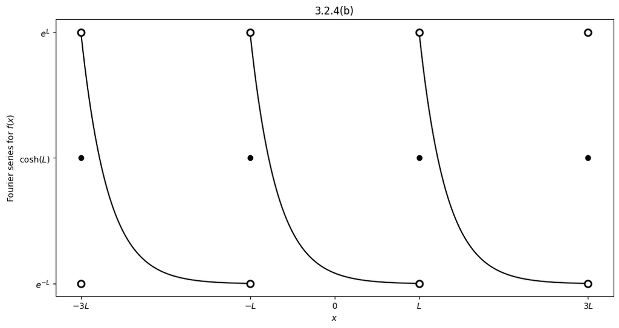

## (c)

$$f(x) = \sin \frac{\pi x}{L}$$

Intuitively, this is already in the form of a Fourier series on $[-L,L],$ and so we expect

$$ \boxed{a_0 = 0, \quad a_n = 0 \text{ for all } n\geq 1, \quad b_1 = 1, \quad b_n = 0 \text{ for all } n \geq 2}.$$

More precisely, odd function properties (or the orthogonality integrals, some of which are a consequence) guarantee

$$a_0 = \frac{1}{2L} \int_{-L}^L \sin \frac{\pi x}{L} \, dx = 0, \qquad a_n = \frac{1}{L} \int_{-L}^L \sin \frac{\pi x}{L} \cos \frac{n \pi x}{L} \, dx = 0$$

since both $\sin \frac{\pi x}{L}$ and $\sin \frac{\pi x}{L} \cos \frac{n \pi x}{L}$ are odd. The orthogonality integrals then show

$$ b_n = \frac{1}{L} \int_{-L}^L \sin \frac{\pi x}{L} \sin\frac{n \pi x}{L} \, dx = \left\{ \begin{array}{rl} \frac 1 L \cdot L = 1, & n=1 \\ \\ \frac 1 L \cdot 0 = 0, & n \geq 2 \end{array} \right. .$$

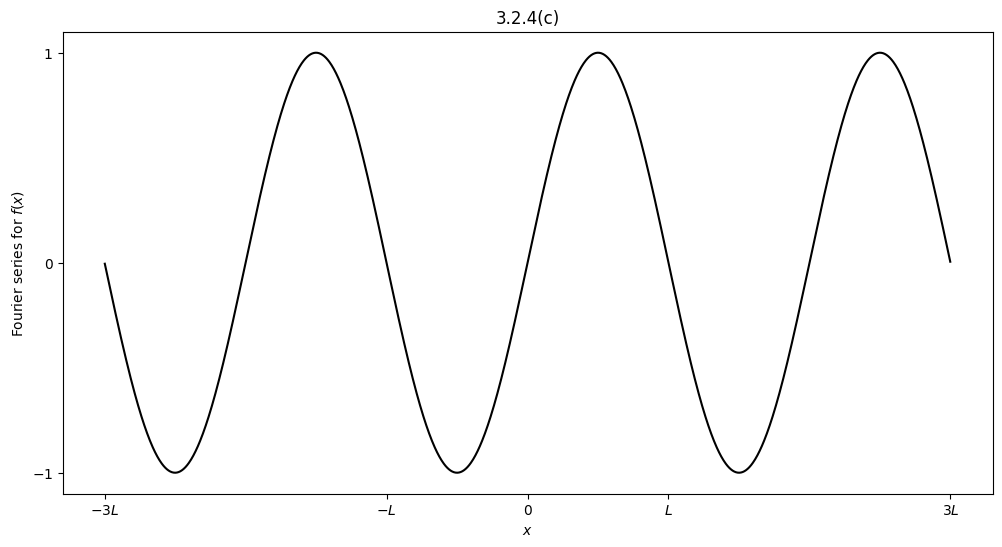

## (d)

$$f(x) = \left\{ \begin{array}{rl} 0 & -L \leq x < 0 \\ x & 0 \leq x < L \end{array} \right. $$

We have

$$ \boxed{a_0} = \frac{1}{2L} \int_{-L}^L f(x) \, dx = \frac{1}{2L} \int_0^L x \, dx = \frac{1}{2L} \cdot \frac{L^2}{2} = \boxed{\frac L 4}.$$

For $a_n$, we integrate by parts to obtain

\begin{align*} \boxed{a_n} &= \frac 1 L \int_{-L}^L f(x) \cos \frac{n \pi x}{L} \, dx \\ &= \frac{1}{L} \int_0^L \underbrace{x}_{u} \underbrace{ \cos\frac{n \pi x}{L}}_{dv} \, dx \\ &= \frac 1 L x \cdot \frac{L}{n \pi} \sin \frac{n \pi x}{L} \Big|_0^L - \frac 1 L \cdot \frac{L}{n\pi} \int_0^L \sin \frac{n \pi x}{L} \, dx \\ &= \frac{L}{n^2 \pi^2} \cos \frac{n \pi x}{L} \Big|_0^L \\ &= \boxed{\frac{L}{n^2 \pi^2}[(-1)^n - 1]}. \end{align*}

Similarly, \begin{align*} \boxed{b_n} &= \frac 1 L \int_{-L}^L f(x) \sin \frac{n \pi x}{L} \, dx \\ &= \frac{1}{L} \int_0^L \underbrace{x}_{u} \underbrace{ \sin\frac{n \pi x}{L}}_{dv} \, dx \\ &= -\frac 1 L x \cdot \frac{L}{n \pi} \cos \frac{n \pi x}{L} \Big|_0^L + \frac 1 L \cdot \frac{L}{n\pi} \int_0^L \cos \frac{n \pi x}{L} \, dx \\ &= -\frac{L}{n\pi}\cos(n\pi) + \left[\frac{L}{n^2 \pi^2} \sin \frac{n \pi x}{L} \Big|_0^L\right] \\ &= \boxed{\frac{L}{n\pi}(-1)^{n+1}}. \end{align*}

We can check our answer with SymPy, and plot the $2L$-periodic extension:

$\displaystyle f(x)\sim a_0 + \sum_{n=1}^\infty a_n \cos \left( \dfrac{n \pi x}{L} \right)+\sum_{n=1}^\infty b_n \sin \left( \dfrac{n \pi x}{L}\right) \text{ on } [-L,L]\\[1em]$

$\displaystyle a_0 = \frac{L}{4} \\[1em]$

$\displaystyle a_n = \frac{L \left(\left(-1\right)^{n} - 1\right)}{\pi^{2} n^{2}}\\[1em]$

$\displaystyle b_n = \frac{\left(-1\right)^{n + 1} L}{\pi n}\\[1em]$

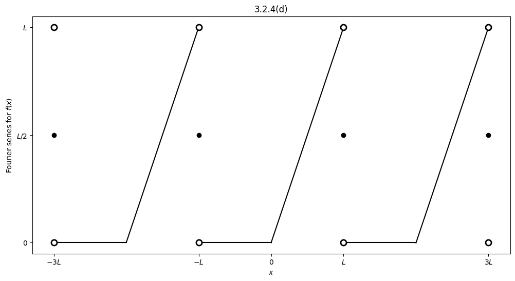

## (e)

$$f(x) = \left\{ \begin{array}{rl} 1 & |x| \leq L/2 \\ 0 & L/2 < |x| \leq L \end{array} \right. $$

Since $f$ is even, we have $$\boxed{b_n = 0 \text{ for all } n}.$$

We have

$$\boxed{a_0} = \frac{1}{2L} \int_{-L}^L f(x) \, dx = \frac{1}{2L} \int_{-L/2}^{L/2} 1 \, dx = \frac{1}{2L} \cdot L = \boxed{\frac 1 2}.$$

Then,

\begin{align*} \boxed{a_n} &= \frac{1}{L} \int_{-L}^L f(x) \cos\frac{n \pi x}{L} \, dx \\ &= \frac{1}{L} \int_{-L/2}^{L/2} \cos \frac{n \pi x}{L} \, dx \\ &= \frac{1}{L} \cdot \frac{L}{n \pi} \sin \frac{n \pi x}{L} \Big|_{-L/2}^{L/2} \\ &= \frac{1}{n \pi} \left[ \sin \frac{n \pi}{2} - \sin \left(- \frac{n\pi}{2}\right)\right] \\ &= \boxed{\frac{2}{n \pi} \sin \frac{n \pi}{2}}. \end{align*}

We could notice

$$ \sin \frac{n\pi}{2} = \left\{ \begin{array}{rl} 1 & n = 4k+1 \text{ for integer } k, \\ -1 & n = 4k+3 \text{ for integer } k, \\ 0 & \text{ otherwise} \end{array}\right. .$$

We can check our answer with Sympy, and plot the $2L$-perioidic extension:

$\displaystyle f(x)\sim a_0 + \sum_{n=1}^\infty a_n \cos \left( \dfrac{n \pi x}{L} \right)+\sum_{n=1}^\infty b_n \sin \left( \dfrac{n \pi x}{L}\right) \text{ on } [-L,L]\\[1em]$

$\displaystyle a_0 = \frac{1}{2} \\[1em]$

$\displaystyle a_n = \frac{2 \sin{\left(\frac{\pi n}{2} \right)}}{\pi n}\\[1em]$

$\displaystyle b_n = 0\\[1em]$

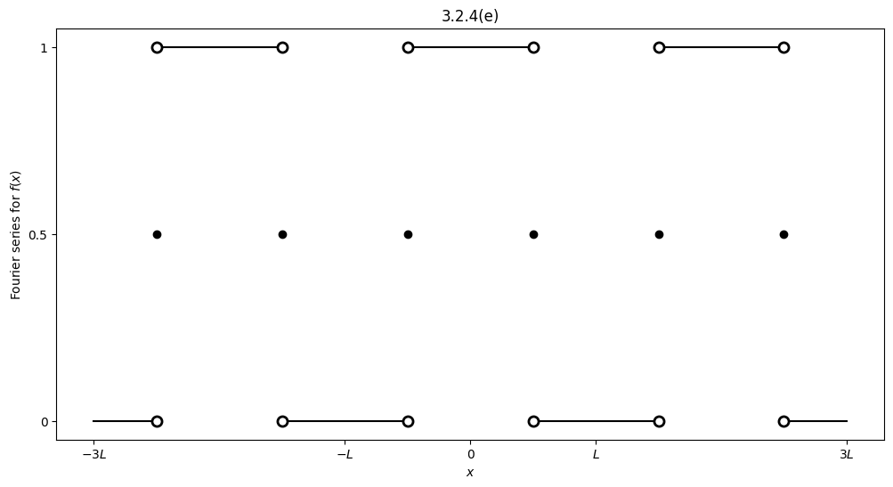

## (f)

$$f(x) = \left\{ \begin{array}{rl} 0 & -L < x < 0 \\ 1 & 0 < x < L \end{array} \right. $$

We have

$$\boxed{a_0} = \frac{1}{2L} \int_{-L}^L f(x) \, dx = \frac{1}{2L} \int_0^L 1 \, dx = \frac{1}{2L} \cdot L = \boxed{\frac 1 2}.$$

Then, \begin{align*} \boxed{a_n} &= \frac{1}{L} \int_{-L}^L f(x) \cos \frac{n \pi x}{L} \, dx \\ &= \frac{1}{L} \int_0^L \cos \frac{n \pi x}{L} \, dx \\ &= \frac{1}{L} \cdot \frac{L}{n \pi} \sin \frac{n \pi x}{L} \Big|_0^L \\ &= \boxed{0}, \end{align*}

and

\begin{align*} \boxed{b_n} &= \frac{1}{L} \int_{-L}^L f(x) \sin \frac{n \pi x}{L} \, dx \\ &= \frac{1}{L} \int_0^L \sin \frac{n \pi x}{L} \, dx \\ &= -\frac{1}{L} \cdot \frac{L}{n \pi} \cos \frac{n \pi x}{L} \Big|_0^L \\ &= -\frac{1}{n\pi} [\cos(n\pi) - 1]\\ &= \boxed{- \frac{1}{n \pi}[(-1)^n - 1]}. \end{align*}

We can check our answer with Sympy, and plot the $2L$-perioidic extension:

$\displaystyle f(x)\sim a_0 + \sum_{n=1}^\infty a_n \cos \left( \dfrac{n \pi x}{L} \right)+\sum_{n=1}^\infty b_n \sin \left( \dfrac{n \pi x}{L}\right) \text{ on } [-L,L]\\[1em]$

$\displaystyle a_0 = \frac{1}{2} \\[1em]$

$\displaystyle a_n = 0\\[1em]$

$\displaystyle b_n = \frac{1 - \left(-1\right)^{n}}{\pi n}\\[1em]$

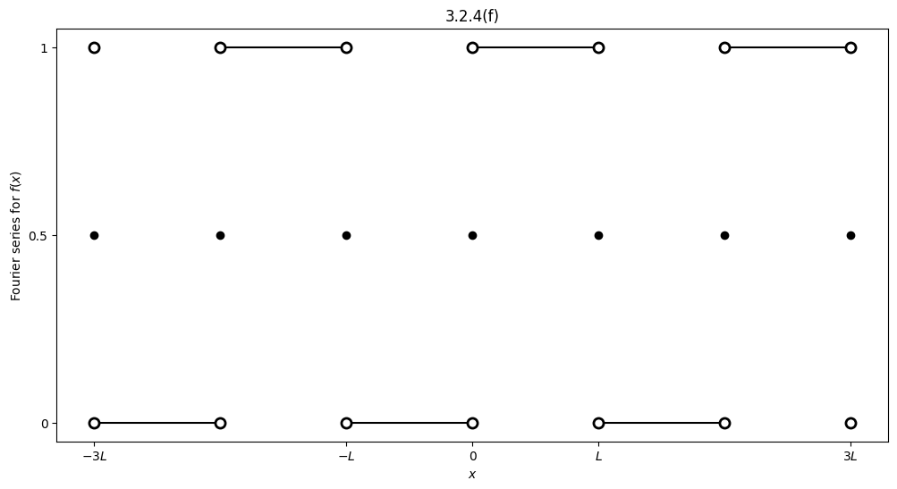

## (g)

$$f(x) = \left\{ \begin{array}{rl} 1 & -L < x \leq 0 \\ 2 & 0 < x < L \end{array} \right. $$

Since the integrals defining the Fourier coefficients don't notice what happens at finitely many values of $x$, as far as Fourier series are concerned this function is simply

$$f(x) = 1 + g(x),$$

were $g(x)$ is the function from the previous part (f).

"Fourier coefficients are linear" in the sense that any Fourier coefficient of a linear combination of functions is that linear combination of those Fourier coefficients. (This makes sense from linearity of integrals.)

Since $1$ is already in the form of a Fourier series on $[-L,L]$ (that is, $a_0 = 1$, $a_n =b_n= 0$ for $n \geq 1$) we can use our answer in part (f) to obtain

\begin{align*} a_0 &= 1 + \frac 1 2 = \frac 3 2, \\ a_n &= 0 + 0 = 0, \\ b_n &= 0 + \left[ - \frac{1}{n \pi}[(-1)^n - 1] \right] = -\frac{1}{n\pi}[(-1)^n - 1]. \end{align*}

Indeed, calculating the integrals directly would show the same, as does SymPy:

$\displaystyle f(x)\sim a_0 + \sum_{n=1}^\infty a_n \cos \left( \dfrac{n \pi x}{L} \right)+\sum_{n=1}^\infty b_n \sin \left( \dfrac{n \pi x}{L}\right) \text{ on } [-L,L]\\[1em]$

$\displaystyle a_0 = \frac{3}{2} \\[1em]$

$\displaystyle a_n = 0\\[1em]$

$\displaystyle b_n = \frac{1 - \left(-1\right)^{n}}{\pi n}\\[1em]$

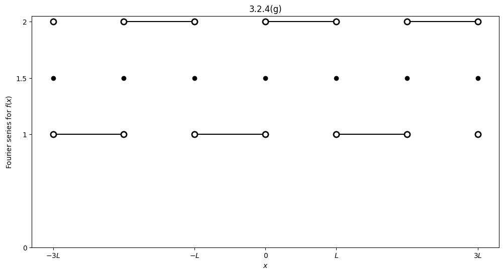

# 3.3.2

## (a)

$$f(x) = 1$$

As $f(x)$ is continuous and perioidic with period $2L$, its Fourier series equals $f(x)$ for all values of $x$.

In addition, since $f(x)$ is also even, its $[0,L]$ Fourier cosine series equals $f(x)$ for all values of $x$.

However, since $f(0) \neq 0, f(L) \neq 0$, its odd $2L$-periodic extension will have jump discontinuities at $0, \pm L, \pm 2L, \pm 3L, ...$ and so the $[0,L]$ Fourier sine series will have these jumps as well.

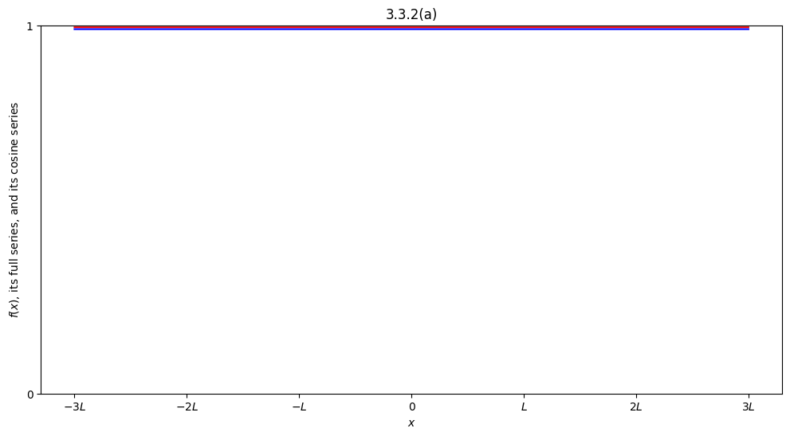

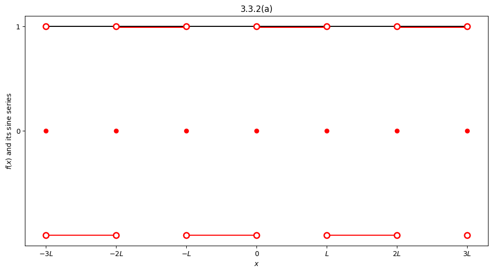

## (b)

$$f(x) = 1+x$$

Since $f(L) \neq f(-L),$ the perioidic extension and hence the full Fourier series will have jumps at $x = \pm L, \pm 3L, ...$ that average to 1.

Since $f(0) \neq 0, f(L) \neq 0$, the odd periodic extension and hence the Fourier sine series will have jumps at $x = 0, \pm L, \pm 2L, \pm 3L, ...$. They all average to 0 in this case.

However, since $f$ is continuous, the even periodic extension and hence the Fourier cosine series will be continuous for all $x$. (This is what we mentioned in class, that the even periodic extension cannot introduce jumps that aren't already present in $f$ between $0 < x < L$.)

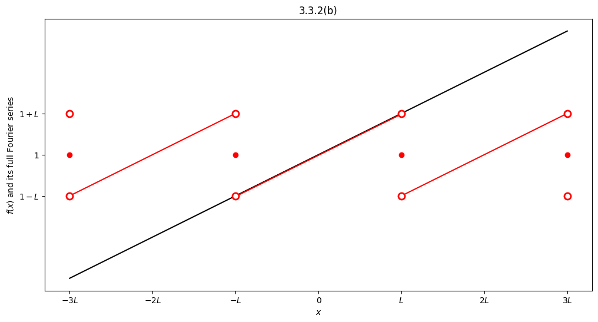

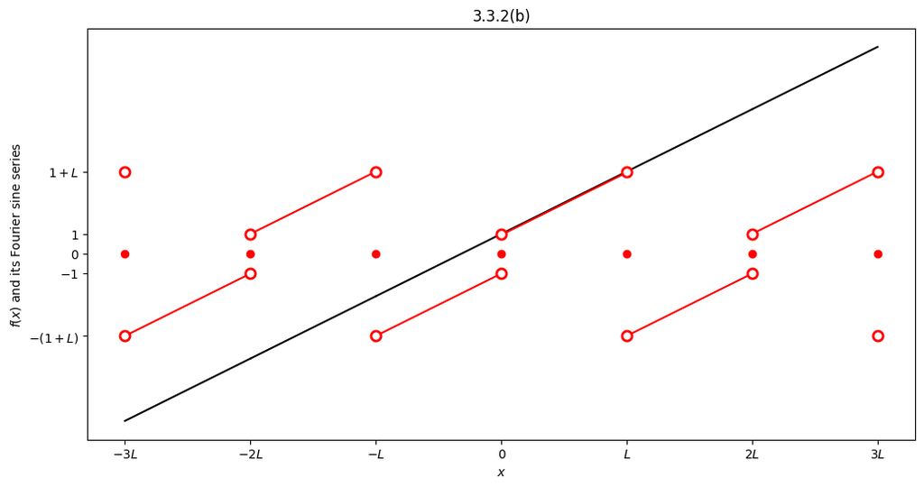

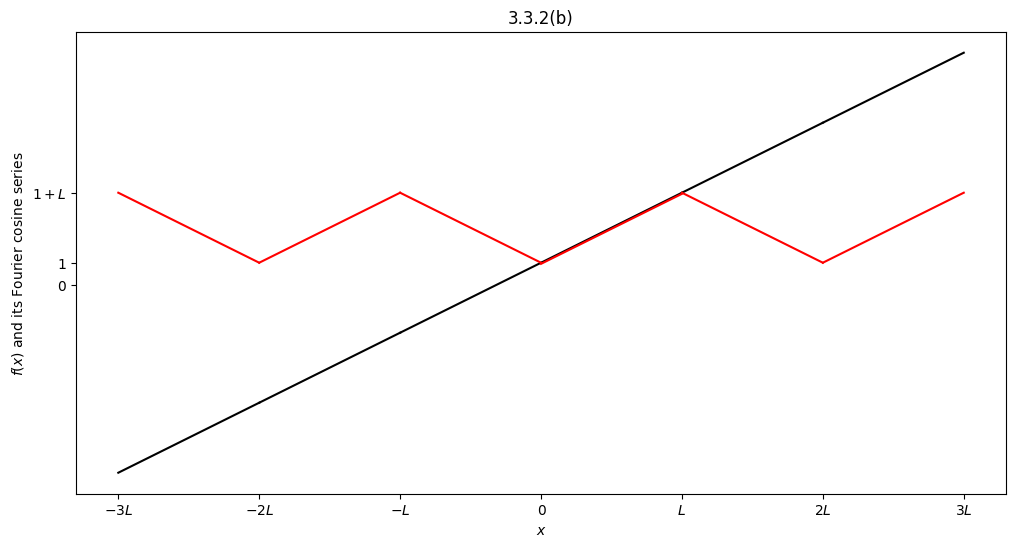

## (c)

$$f(x) = \left\{ \begin{array}{ll} x & x < 0 \\ 1 + x & x > 0 \end{array} \right. .$$

$f$ is not continuous at $x=0$, and since $f(L) \neq f(-L)$ its peirodic extension will introduce additional jumps. Together, the perioidic extension and hence the full Fourier series will have jumps at $x=0, \pm L, \pm 2L, \pm 3L, ...$. The jumps at $x = 0, \pm 2L, \pm 4L, ...$ will average to $\frac 1 2,$ while the jumps at $x = \pm L, \pm 3L, \pm 5L, ...$ will average to 1.

Since the $[0,L]$ cosine series and $[0,L]$ sine series only use the behavior of $f$ on $[0,L]$, **these will be the same as those series from part (b) above**.

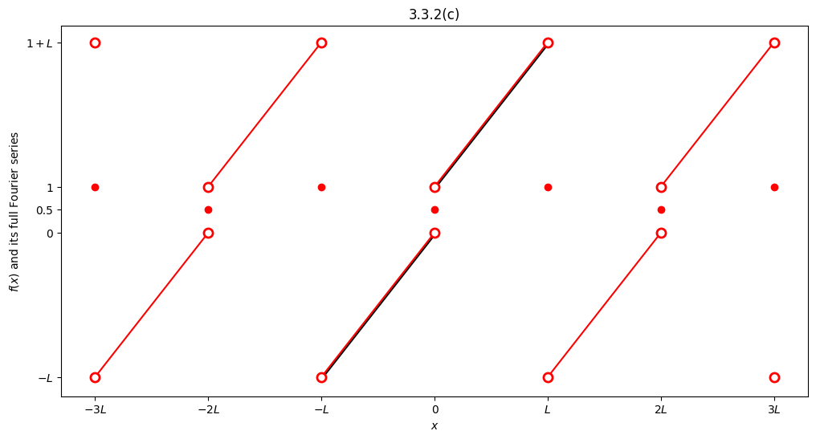

## (d)

$$f(x) = e^x$$

Since $e^L \neq e^{-L},$ the perioidic extension will introduce jumps at $x = \pm L, \pm 3L, \pm 5L, ...$, with average given by $\frac{e^L + e^{-L}}{2} = \cosh(L).$

Since $e^L \neq e^{-L}$ and $e^0 \neq 0$, the odd perioidic extension and hence the Fourier sine series will have jumps at $x=0, \pm L, \pm 2L, \pm 3L, ...$$ all of which will average to 0.

Since $e^x$ is continuous, the even perioidic extension and hence the Fourier cosine series will also be continuous.

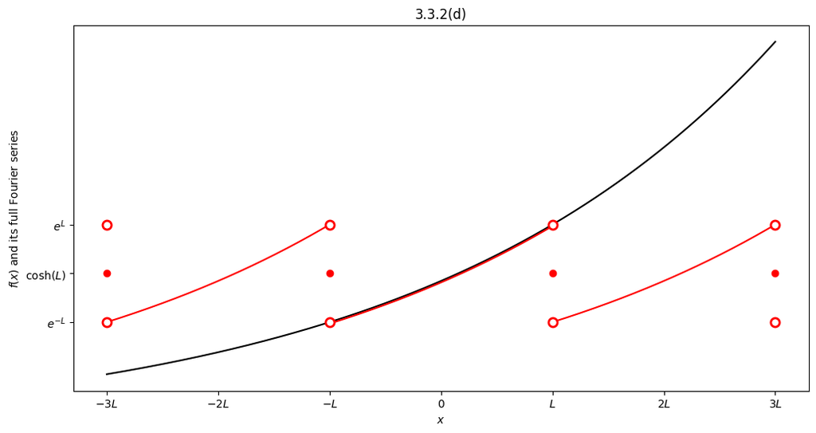

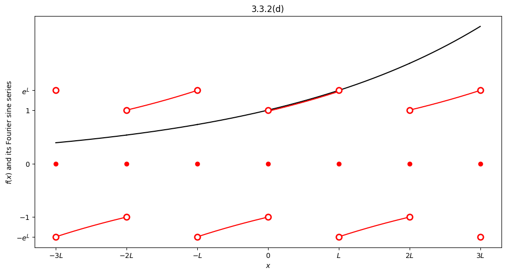

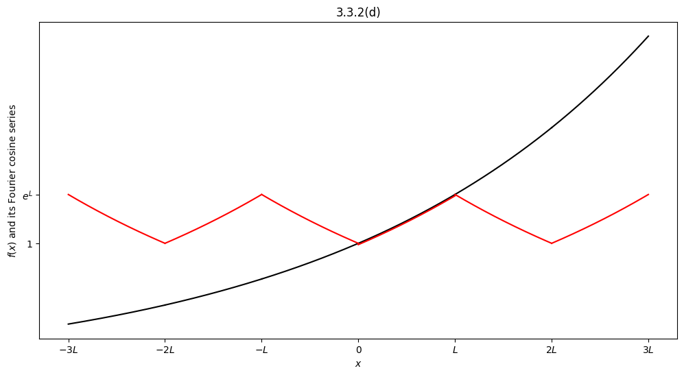

## (e)

$$f(x) = \left\{ \begin{array}{ll} 2 & x < 0 \\ e^{-x} & x > 0 \end{array} \right. .$$

$f$ is not continuous at $0$, and $f(L) \neq f(-L)$ (since $e^L < $ for any $L>0$) and so the perioidic extension and full Fourier series will have jumps at $x=0, \pm L, \pm 2L, \pm 3L, ...$. The jumps at $x=0, \pm 2L, \pm 4L, ...$ will average to $\dfrac 3 2$, and the jumps at $x=\pm L, \pm 3L, \pm 5L, ...$ will average to $\dfrac{2 + e^{-L}}{2}.$

For the Fourier sine seires, $f(0) \neq 0, f(L) \neq 0$ and so it will have jumps at $x=0, \pm L, \pm 2L, \pm 3L, ...$ that average to 0.

As $f$ is continuous on $[0,L]$, the Fourier cosine series will be continuous for all $x$.

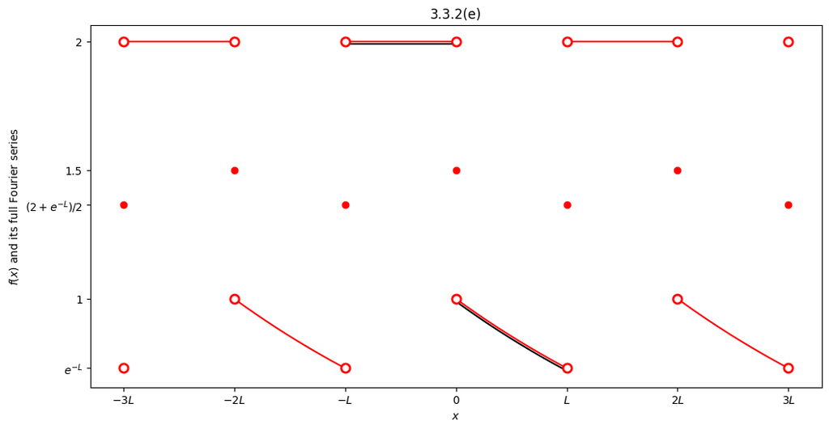

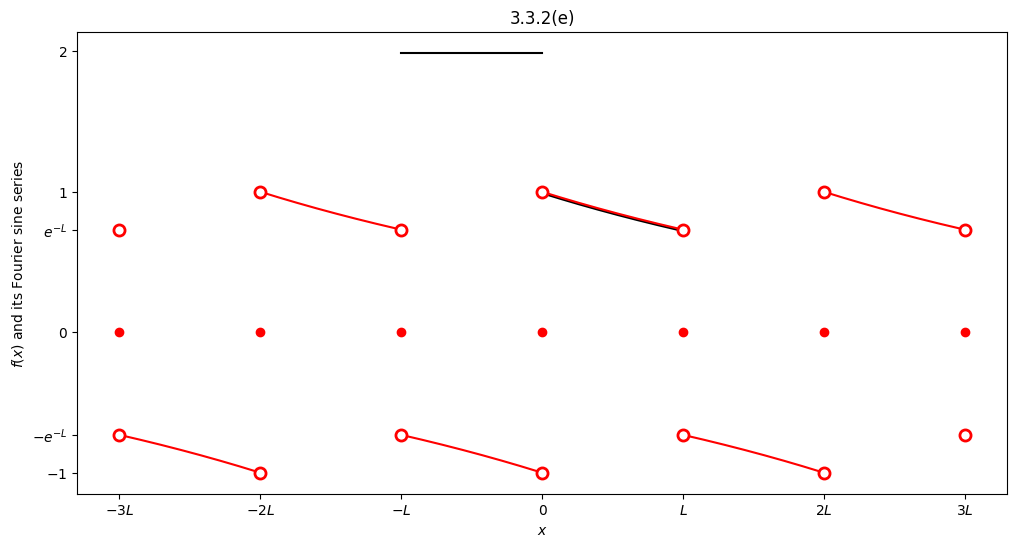

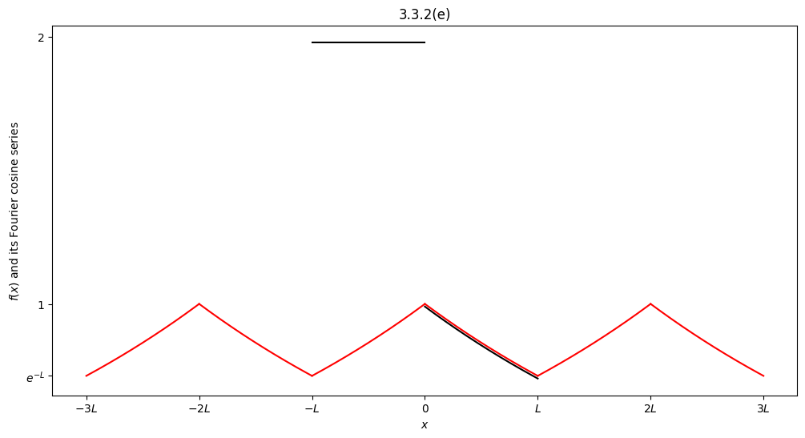

# 3.3.3

## (a)

$$f(x) = \cos \frac{\pi x}{L}$$

We have

$$B_n = \frac 2 L \int_0^L \cos \frac{\pi x}{L} \sin \frac{n \pi x}{L} \, dx.$$

For $n=1$ we quickly see

$$B_1 = \frac 2 L \int_0^L \cos \frac{\pi x}{L} \sin \frac{\pi x}{L} \, dx = \frac 1 L \cdot \frac{L}{\pi} \sin^2 \frac{\pi x}{L} \Big|_0^L = 0.$$

For $n \geq 1,$ we'll need the identity

$$ \sin a \cos b = \frac 1 2 [ \sin(a+b) + \sin(a-b)].$$

Therefore, we have (notice the below is not valid for $n=1$, which is why we separated that case)

\begin{align*} B_n &= \frac 1 L \int_0^L \left[ \sin \frac{(n+1)\pi x}{L} + \sin \frac{(n-1) \pi x}{L} \right] \, dx \\ &= - \frac 1 L \left[ \frac{L}{(n+1) \pi} \cos \frac{(n+1)\pi x}{L} + \frac{L}{(n-1)\pi} \cos \frac{(n-1)\pi x}{L} \right] \Big|_0^L \\ &= - \frac 1 L \left[ \frac{L}{(n+1)\pi} \left( \cos[(n+1)\pi] - 1 \right) + \frac{L}{(n-1) \pi} \left( \cos[(n-1)\pi] - 1 \right) \right] \end{align*}

If $n$ is odd, then $\cos[(n+1)\pi] = \cos[(n-1)\pi] = 1$ and so $B_n = 0$.

If $n$ is even, then $\cos[(n+1)\pi] = \cos[(n-1)\pi] = -1$ leading to

$$B_n = - \frac{1}{L} \left[ \frac{L}{(n+1)\pi}\cdot(-2) + \frac{L}{(n-1)\pi}\cdot(-2)\right] = \frac{2}{\pi} \left[ \frac{1}{n+1} + \frac{1}{n-1} \right] = \frac{2}{\pi} \cdot \frac{2n}{n^2-1} = \frac{4n}{\pi(n^2-1)}.$$

Putting it toegher,

$$ \boxed{B_n = \left\{ \begin{array}{ll} 0 & n \text{ odd} \\ \dfrac{4n}{\pi(n^2-1)} & n \text{ even} \end{array} \right.} .$$

We can check our answer with SymPy (notice its answer is equivalent to ours, just written differently), and plot the odd $2L$-perioidic extension:

$\displaystyle f(x)\sim \sum_{n=1}^\infty b_n \sin \left( \dfrac{n \pi x}{L}\right) \text{ on } [0,L]\\[1em]$

$\displaystyle b_n = \begin{cases} \frac{2 n \left(\left(-1\right)^{n} + 1\right)}{\pi \left(n^{2} - 1\right)} & \text{for}\: n > 1 \\0 & \text{otherwise} \end{cases}\\[1em]$

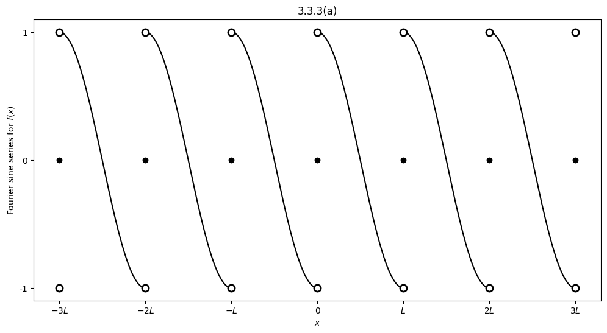

## (b)

$$f(x) = \left\{ \begin{array}{rl} 1 & x < \frac L 6 \\ 3 & \frac L 6 < x < \frac L 2 \\ 0 & x > \frac L 2 \end{array} \right. $$

We have

\begin{align*} \boxed{B_n} &= \frac{2}{L} \int_0^L f(x) \sin \frac{n \pi x}{L} \, dx \\ &= \frac 2 L \int_0^{L/6} \sin \frac{n \pi x}{L} \, dx + \frac 2 L \int_{L/6}^{L/2} 3 \sin \frac{ n \pi x}{L} \, dx \\ &= - \frac 2 L \cdot \frac{L}{n \pi} \cos \frac{n \pi x}{L} \Big|_0^{L/6} - \frac 2 L \cdot \frac{L}{n \pi} 3 \cos \frac{n \pi x}{L} \Big|_{L/6}^{L/2} \\ &= - \frac{2}{n \pi} \left[ \cos \frac{n \pi}{6} - 1 \right] - \frac{6}{n\pi} \left[ \cos \frac{n \pi}{2} - \cos \frac{n \pi}{6} \right]\\ &= \frac{2}{n\pi} \left[ - \cos \frac{n \pi}{6} + 1 -3 \cos \frac{n \pi}{2} + 3 \cos \frac{n \pi}{6} \right] \\ &= \boxed{\frac{2}{n\pi} \left[ 2 \cos \frac{n \pi}{6} - 3 \cos \frac{n \pi}{2} + 1 \right]}. \end{align*}

We could write out what these are in terms of whether $n = 12k, 12k+1, 12k+2, ..., 12k+11$ for integer $k$, since the $2\pi$-periodicity of cosine ensures $B_n = B_{n+12} = B_{n + 24} = \cdots$, and we know the exact cosine values at these special angles.

We can check our answer with SymPy, and plot the odd $2L$-perioidic extension:

$\displaystyle f(x)\sim \sum_{n=1}^\infty b_n \sin \left( \dfrac{n \pi x}{L}\right) \text{ on } [0,L]\\[1em]$

$\displaystyle b_n = \frac{2 \left(2 \cos{\left(\frac{\pi n}{6} \right)} - 3 \cos{\left(\frac{\pi n}{2} \right)} + 1\right)}{\pi n}\\[1em]$

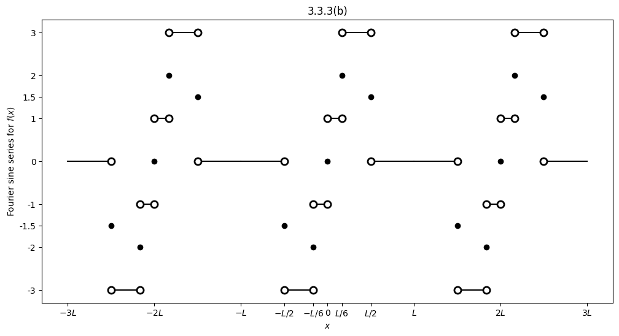

## (c)

$$f(x) = \left\{ \begin{array}{rl} 0 & x < \frac L 2 \\ x & x > \frac L 2 \end{array} \right. $$

We have

We can check our answer with SymPy, and plot the odd $2L$-perioidic extension:

$\displaystyle f(x)\sim \sum_{n=1}^\infty b_n \sin \left( \dfrac{n \pi x}{L}\right) \text{ on } [0,L]\\[1em]$

$\displaystyle b_n = - \frac{L \left(\pi n \left(2 \left(-1\right)^{n} - \cos{\left(\frac{\pi n}{2} \right)}\right) + 2 \sin{\left(\frac{\pi n}{2} \right)}\right)}{\pi^{2} n^{2}}\\[1em]$

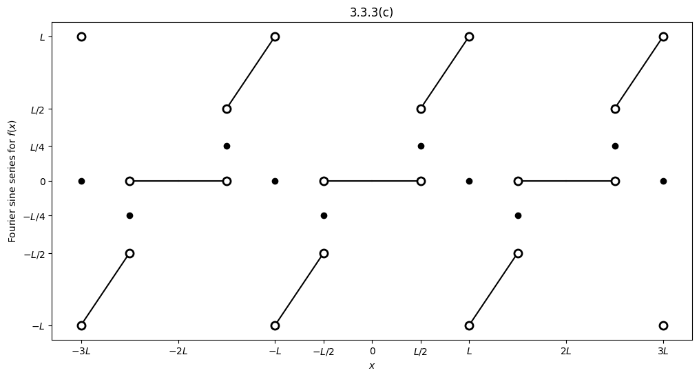

## (d)

$$f(x) = \left\{ \begin{array}{rl} 1 & x < \frac L 2 \\ 0 & x > \frac L 2 \end{array} \right. $$

We have

\begin{align*} \boxed{B_n} &= \frac 2 L \int_0^L f(x) \sin \frac{n \pi x}{L} \, dx \\ &= \frac 2 L \int_0^{L/2} \sin \frac{n \pi x}{L} \, dx \\ &= - \frac 2 L \cdot \frac{L}{n \pi} \cos \frac{n \pi x}{L} \Big|_0^{L/2} \\ &= - \frac{2}{n \pi} \left[ \cos \frac{n \pi}{2} - 1 \right]\\ \\ &= \boxed{ \left\{ \begin{array}{ll} 0 & n = 4k \text{ for integer } k \\ \\ \dfrac{2}{n \pi} & n = 4k+1 \text{ or } 4k+3 \text{ for integer } k \\ \\ \dfrac{4}{n\pi} & n = 4k+2 \text{ for integer } k \end{array} \right. } \end{align*}

We can check our answer with SymPy, and plot the odd $2L$-perioidic extension:

$\displaystyle f(x)\sim \sum_{n=1}^\infty b_n \sin \left( \dfrac{n \pi x}{L}\right) \text{ on } [0,L]\\[1em]$

$\displaystyle b_n = \frac{2 \left(1 - \cos{\left(\frac{\pi n}{2} \right)}\right)}{\pi n}\\[1em]$

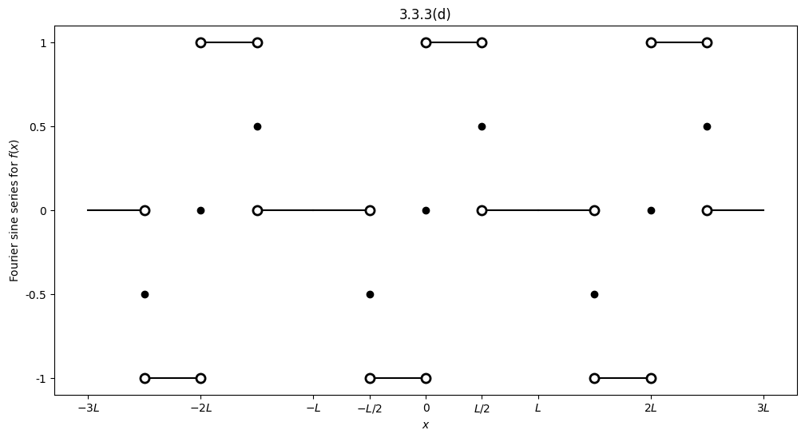

# 3.4.13

Following my hint, notice that $A(t)\left( 1 - \frac x L \right)$ equals $A(t)$ along $x=0$ for all $t$, and equals $0$ along $x=L$ for all $t$. Therefore, $$v(x,t) := u(x,t) - A(t) \left( 1 - \frac x L \right)$$ has homogeneous boundary conditions at $x=0,L$ so we assume has an eigenfunction expansion (see 3.4.15) in the form of a **continuous sine series**, which allows it to be differentiated term-by-term. That is, we seek a solution of the form $$v(x,t) = \sum_{n=1}^\infty B_n(t) \sin\left( \frac{n \pi x}{L} \right).$$ We have $$ \frac{\partial^2}{\partial x^2} A(t) \left( 1 - \frac x L \right) = 0, \qquad \frac{\partial}{\partial t} A(t) \left( 1 - \dfrac x L \right) = A'(t) \left( 1 - \dfrac x L \right)$$ and so using the PDE/initial/BC for $u$ we see that $v$ solves $$ \left\{ \begin{array}{rl} \dfrac{\partial v}{\partial t} &= k \dfrac{\partial^2 v}{\partial x^2} - A'(t) \left( 1 - \dfrac x L \right) \\ \\ v(0,t) &=v(L,t) = 0 \\ \\ v(x,0) &= g(x) - A(0) \left( 1 - \dfrac x L \right) \end{array} \right. .$$ As discussed in class, spatial differentiation of Fourier series can be tedious but due to $v$ having homogeneous boundary conditions everything works as expected. Therefore, using our ansatz for $v(x,t)$ we decided above: we substitute $$ \frac{\partial v}{\partial t} = \sum_{n=1}^\infty B_n'(t) \sin\left( \frac{n \pi x}{L} \right), \qquad \frac{\partial^2 v}{\partial x^2} = \sum_{n=1}^\infty B_n(t) \left( - \frac{n^2 \pi^2}{L^2} \right) \sin\left( \frac{n \pi x}{L} \right)$$ into the PDE (move all the trig terms to the left) to obtain $$ \sum_{n=1}^\infty \underbrace{\left( B_n'(t) + \frac{k n^2 \pi^2}{L^2} B_n(t) \right)}\sin\left( \frac{n \pi x}{L} \right) = - A'(t) \left( 1 - \frac x L \right).$$ Then, using our usual shortcut with the reference table formulas, we have $$ \left( B_m'(t) + \frac{k m^2 \pi^2}{L^2} B_m(t) \right) = \dfrac 2 L \int_0^L \left[- A'(t) \left( 1 - \frac x L \right)\right]\sin\left( \frac{m \pi x}{L} \right) \, dx = -A'(t) \frac{2}{\pi m},$$ where we integrate by parts / use Python to evaluate the Fourier sine coefficients of $\left(1 - \frac x L\right).$

$\displaystyle f(x)\sim \sum_{n=1}^\infty b_n \sin \left( \dfrac{n \pi x}{L}\right) \text{ on } [0,L]\\[1em]$

$\displaystyle b_n = \frac{2}{\pi n}\\[1em]$

Finally, the last thing we haven't used is the initial condition on $v$, which gives us the Fourier coefficients at $t=0$: $$ g(x) - A(0) \left( 1 - \frac x L \right) = \sum_{n=1}^\infty \underbrace{B_n(0)} \sin \left( \frac{n \pi x}{L} \right),$$ and the same idea yields $$ B_m(0) = \frac 2 L \int_0^L g(x) \sin\left( \frac{m \pi x}{L} \right)\, dx - A(0)\frac{2}{m\pi}.$$ Putting it all together, given the prescribed left temperature $A(t)$ and initial temperature $g(x)$, we build $$\fbox{$v(x,t) = \sum_{n=1}^\infty B_n(t) \sin\left( \frac{n \pi x}{L} \right)$}$$ where $$ \fbox{$B_n'(t) + \frac{k n^2 \pi^2}{L^2} B_n(t) = -\frac{2A'(t)}{ \pi n}, \qquad B_n(0) = \frac 2 L \int_0^L g(x) \sin\left( \frac{n \pi x}{L} \right)\, dx - A(0) \frac{2}{n \pi}, \qquad n \geq 1$}.$$ Then, $\boxed{u(x,t) = v(x,t) + A(t) \left( 1 - \frac x L \right)}$.

Note that the ODEs for $B_n(t)$ are all first-order linear, so could be solved with the integrating factor method (which is actually the first order linear ODE manifestation of variation of parameters...).

**By changing dependent variables appropriately, we are able to change an inhomogeneous boundary condition into a homogeneous boundary condition.** The sacrifice here is our PDE is no longer homogeneous, but we were able to use orthoganality to find decoupled ODEs for all time-dependent Fourier coefficients.

# 3.5.6

Substituting $x=0$ into (3.5.5), we have $$0 = \dfrac L 2 - \frac{4L}{\pi^2} \left( 1 + \frac{1}{3^2} + \frac{1}{5^2} + \cdots \right).$$ Rearranging, we have $$S_{\mbox{\small{odd}}}:= 1 + \frac{1}{3^2} + \frac{1}{5^2} + \cdots = \frac{\pi^2}{8}.$$ Let's call $$S := 1 + \frac{1}{2^2} + \frac{1}{3^2} + \cdots,$$ and $$ S_{\mbox{\small{even}}} := \frac{1}{2^2} + \frac{1}{4^2} + \frac{1}{6^2} + \cdots = \frac{1}{2^2} \left( 1 + \frac{1}{2^2} + \frac{1}{3^2} + \cdots\right) = \frac S 4.$$ Since absolutely convergent series can be reordered without changing the sum, we must have $$S =S_{\mbox{\small{odd}}} + S_{\mbox{\small{even}}} = \frac{\pi^2}{8} + \frac{S}{4} \implies \dfrac{3S}{4} = \dfrac{\pi^2}{8}.$$ Then, $S = \fbox{$\dfrac{\pi^2}{6}$}$.